# Time Series Homework: Chapter 2 Lesson 3

Tristan

## Data

```r
ind_prod <- rio::import("https://byuistats.github.io/timeseries/data/ind_prod_us.csv")
```

**Revisions**

I change my question 2 analysis, changed my decomposition model from additive to multiplicative and updated the analysis.

## Questions

### Question 1 - Context and Measurement (10 points)

The first part of any time series analysis is context. You cannot properly analyze data without knowing what the data is measuring. Without context, the most simple features of data can be obscure and inscrutable. This homework assignment will center around the series below.

Please research the time series. In the spaces below, give the data collection process, unit of analysis, and meaning of each observation for the series.

#### **Total US Industrial Production Index**

https://fred.stlouisfed.org/series/IPB50001N

**Answer**

*Data collection process:*

This data is a collected using a combination of surveys, admin records, and industrial reports including Manufacturers’ Shipments, Inventories, and Orders Survey (M3), Current Industrial Reports (CIR), U.S. Geological Survey (USGS), Energy Information Administration (EIA) and company reports. This data is collected monthly.

*Units of Analysis:*

This index includes the manufacturing, mining, and utilities sectors with each industry contributing to the total index base on its proportion of total industrial value added.

*Observations:*

Each monthly observation represents the level of total industrial production in the U.S. during that month relative to 2017.

### Question 2 - Total US Industrial Production: Correlogram (20 points)

##### a) Please plot a correlogram of the US Industrial Production Index

**Answer**

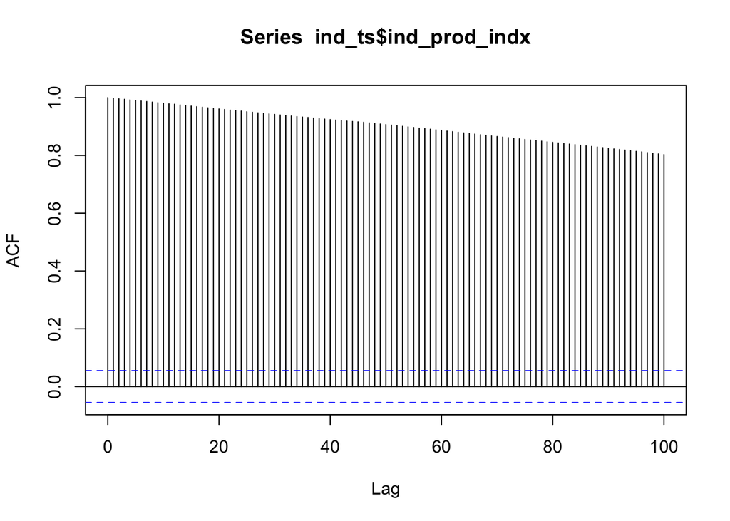

```r
ind_ts <- ind_prod |>
  mutate(
    date2 = mdy(date),
    year_month = yearmonth(date2)
  ) |>
  select(year_month, ind_prod_indx) |>
  tsibble(
    index = year_month
  )

ind_decomp <- ind_ts |>
  model(feasts::classical_decomposition(ind_prod_indx, type = "mult")) |>
  components()

acf(ind_ts$ind_prod_indx, plot = TRUE, type = "correlation", lag.max = 100)
```

##### b) Please identify evidence of any trend or seasonal component using the correlogram. Please justify your findings.

**Answer**

The correlogram doesn’t appear to show of a seasonal component as there are not spikes or repetition of patterns. The slow decrease in values over the correlogram does signify a trend. Removing the trend component may reveal a seasonal component.

### Question 3 - Total US Industrial Production: Decomposition (10 points)

##### a) Please plot a decomposition of the US Industrial Production Index series. Include the original series, trend, seasonal variation, and random component.

**Answer**

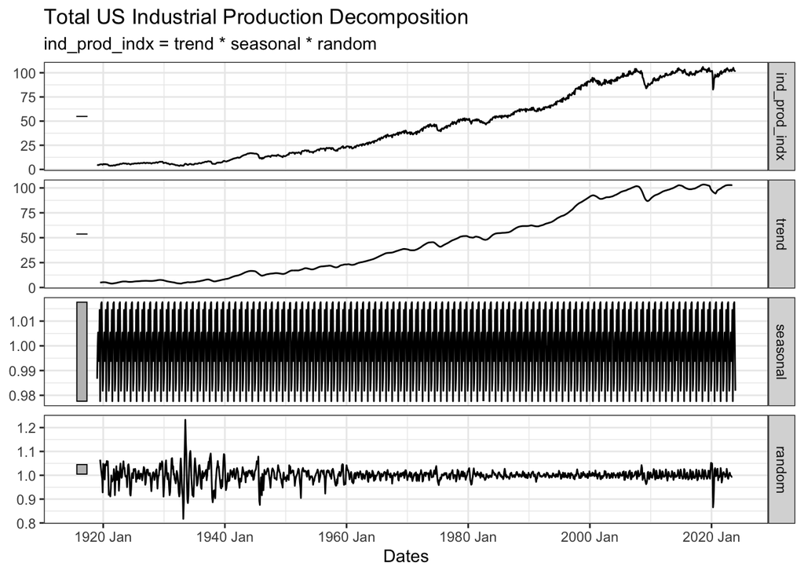

```r
autoplot(ind_decomp) +
  labs(
    title = "Total US Industrial Production Decomposition",
    x = "Dates"
  ) +
  theme_bw()
```

##### b) Justify your choice of decomposition model (additive vs multiplicative)

The multiplicative model does have a greater variation in its random component which we have used a indicator goodness of fit, however the data does have an increasing trend and increasing variation in the seasonal component. Even though the random component may have more variation the multiplicative model better represents the data by capturing historical events that did impact industrial production.

**Answer**

[figure not shown]

```r
ggplot(ind_decomp, aes(x = year_month, y = random)) +
  geom_line() +
  labs(
    title = "US Total Industrial Production Index (1980-2025)",
    x = "Dates",
    y = "Index Level"
  ) +
  theme_bw() +
  theme(plot.title = element_text(hjust = 0.5))
```

### Question 4 - Total US Industrial Production: Stationary Series (20 points)

##### a) Please plot a correlogram of the random component of the US Industrial Production Index

**Answer**

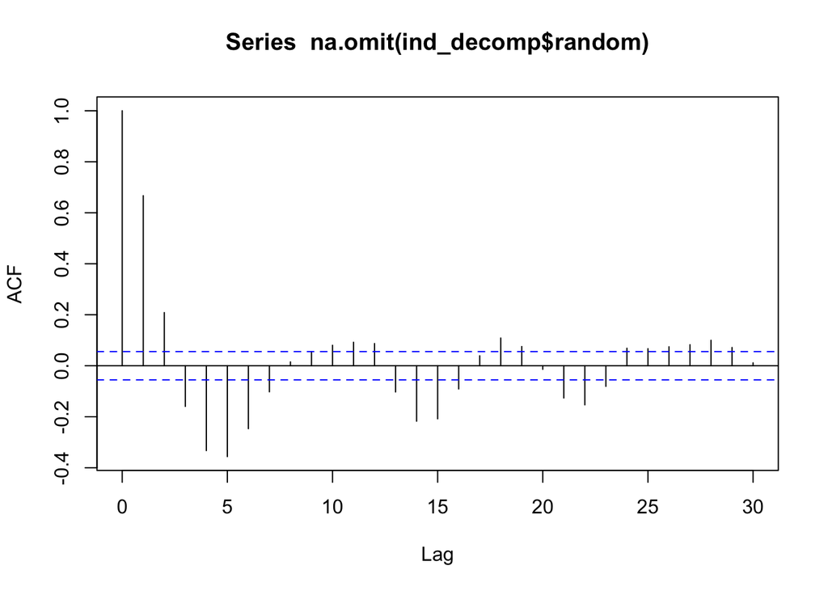

```r
acf(ind_decomp$random |> na.omit(), plot = TRUE, type = "correlation")
```

### Question 5 - US Industrial Production Index: Introspection (20 points)

##### a) Why is it important to remove trend and seasonal variation before plotting and analyzing correlograms?

**Answer**

The trend and seasonal components can introduce substantial noise into the correlogram, potentially obscuring significant patterns or correlations. This effect is evident when comparing the overall correlogram with the one based on the random component. While the original correlogram offers limited interpretability, the random component’s correlogram provides clearer and more meaningful insights.

##### b) Please speculate on the importance of autocorrelation analysis of the random component of time series data on its modeling and investigation?

**Answer**

Significant correlation in the random component could be a sign that the model does not capture the full seasonality or trend in the data. This could affect forecasting accuracy or insights drawn from the model.

### Rubric

[output not shown]